# Riego Inteligente Parte II: Clustering y regresión

Paula Susana Gómez Bernal

25/1/2022

# 1 Configuración

```r
source(file.path("code","include.R"), encoding = "UTF-8")
dirs$data <- "datosTFG"
dflt$ini <- as.Date("2019-01-01")
dflt$fin <- as.Date("2021-05-17")
```

```r
sum.period <- function(...) {
  v <- c(...)
  lubridate::seconds_to_period(sum(lubridate::period_to_seconds(v)))
}
```

# 2 Tarea 5.1. Primeros modelos y resultados (`ML.R`)

## 2.1 Valores por defecto

> **¡IMPORTANTE!** Modelo de regresión por defecto: `dflt$model`. Otros modelos de regresión: `dflt$models`. [Otros modelos disponibles](https://topepo.github.io/caret/available-models.html).

```r
dflt$models
```

```
## [1] "glm"       "rpart"     "knn"       "svmRadial" "gbm"       "rf"
```

```r
dflt$model
```

```
## [1] "rf"
```

## 2.2 Procesamiento

> La función que hay que llamar para probar los escenarios 1 (un modelo para todos los contratos) y 2 (un modelo para cada contrato) es `ML$initResultsNone()`. Ésta se apoya en `ML$probarModelo()` y en `ML$promediarResults()`.

Como siempre, tenemos los parámetros `ind(s)`, `mask(s)`, `agg(s)`, `crop(s)`, `int(s)` para indicar el conjunto de datos sobre el que probar los modelos `model(s)`. Naturalmente, solo se puede probar para los contratos que tienen dicho conjunto de datos.

`ML$promediarResults()` simplemente saca la media de los resultados del escenario 2 y suma los tiempos de ejecución para obtener el tiempo total.

> La función principal encargada de obtener los resultados y guardarlos en un fichero especial para evitar repetir las mismas pruebas (esto será cuando usemos clustering) es `ML$probarModelo()`, **que está paralelizada**.

Esta función, dado uno o varios contratos,

- lee sus datos (`DatInt$readDatInt()`),
- los particiona **aleatoriamente** en train y test (`ML$particionarDatos()`),
- los preprocesa/**normaliza** aplicando **opcionalmente PCA** (`ML$preprocesarDatos()`),
- entrena varios modelos con los datos de train optimizando los parámetros de ajuste (`ML$entrenarModelo()`),
- y evalúa el modelo final sobre los datos de test (`ML$testearModelo()`).

> **¡IMPORTANTE!** Hay que tener en cuenta,
> - que el particionamiento se realiza para cada contrato y después se juntan los distintos train/test.
> - Se puede no aplicar PCA, i.e., PCA=0 (`byPCA=0L`) o probar todas las posibilidades, i.e., PCA=0,1,2…,#predicctores (`byPCA=1L`).
> - Para optimizar los parámetros se usa 10-fold CV con 10 repeticiones (`control=ML$control`).
> - `caret` prueba con unos parámetros por defecto, que puede que no sean los adecuados dependiendo de la cantidad de observaciones disponibles llevando a errores (como pasa en el escenario 2) o sobreajuste. Para estudiar esto se puede también evaluar el modelo final sobre los datos de train (`extended=T`).
> - **Si se usa un modelo específico de prediccion de series (como LSTM), muchos de los pasos deberían cambiar (ver última sección)**.

```r
# No ejecutar (tarda más de 3d)
ML$initResultsNone(inds = dflt$ind, masks = unique(c(NA,dflt$mask)),
                   aggs = dflt$agg, crops = dflt$crop, ints = dflt$ints,
                   models = dflt$models[5:6], byPCA = 1L, control = ML$control)
```

> `gbm` y `svmRadial` tienen un tiempo de ejecución aceptable. `rf` tarda muuucho tiempo…

## 2.3 Leyendo los ficheros

Para leer el fichero especial donde `ML$probarModelo()` guarda los resultados de un conjunto de datos y un modelo:

```r
str(ML$leerResults())
```

```
## Classes 'data.table' and 'data.frame':   5819 obs. of  12 variables:
##  $ Group  : chr  "6351960" "6351960" "6351960" "6351960" ...
##  $ N      : int  1 1 1 1 1 1 1 1 1 1 ...
##  $ PCA    : int  0 1 2 3 4 5 6 7 8 9 ...
##  $ MAE    : num  0.0643 0.0772 0.0826 0.0819 0.0726 ...
##  $ MAPE   : num  0.102 0.119 0.129 0.127 0.114 ...
##  $ MSE    : num  0.00633 0.0106 0.01001 0.00911 0.00781 ...
##  $ RMSE   : num  0.0796 0.1029 0.1001 0.0955 0.0884 ...
##  $ CV     : num  0.689 0.689 0.689 0.689 0.689 ...
##  $ CVRMSE : num  0.116 0.149 0.145 0.139 0.128 ...
##  $ user   : num  0.58 0.49 0.51 0.57 0.63 ...
##  $ system : num  0.05 0.05 0.04 0 0.02 ...
##  $ elapsed: num  8.67 0.82 0.91 1.44 2.04 ...
##  - attr(*, ".internal.selfref")=<externalptr>
##  - attr(*, "param")=List of 6
##   ..$ ind  : chr "NDVI"
##   ..$ mask : chr "scl_7_8_9"
##   ..$ agg  : chr "Mean"
##   ..$ crop : chr "tall"
##   ..$ int  : chr "redim"
##   ..$ model: chr "rf"
```

- `Group` guarda los contratos separados por `_`.
- `N` indica el número de contratos que hay en `Group`.
- `PCA`
- `MAE`, `MAPE`, `MSE`, `RMSE`, `CVRMSE`
- `CV` es la media de las observaciones de test, el cociente de `CVRMSE=RMSE/CV`.
- `user`, `system`, `elapsed`

Para leer los resultados de un conjunto de datos y un modelo para los escenarios 1 y 2:

```r
str(ML$leerResultsNone())
```

```
## Classes 'data.table' and 'data.frame':   34 obs. of  11 variables:
##  $ n      : int  1 1 1 1 1 1 1 1 1 1 ...
##  $ PCA    : int  0 1 2 3 4 5 6 7 8 9 ...
##  $ MAE    : num  0.0656 0.1406 0.1092 0.0873 0.0833 ...
##  $ MAPE   : num  0.268 0.546 0.426 0.346 0.332 ...
##  $ MSE    : num  0.00895 0.03138 0.02015 0.01355 0.01255 ...
##  $ RMSE   : num  0.0946 0.1772 0.142 0.1164 0.112 ...
##  $ CV     : num  0.392 0.392 0.392 0.392 0.392 ...
##  $ CVRMSE : num  0.241 0.451 0.362 0.297 0.285 ...
##  $ user   : num  41.1 14.3 19.1 18.2 18.1 ...
##  $ system : num  0.26 0.2 0.17 0.13 0.14 0.27 0.28 0.11 0.19 0.17 ...
##  $ elapsed: num  2952 322 442 911 1507 ...
##  - attr(*, ".internal.selfref")=<externalptr>
##  - attr(*, "param")=List of 7
##   ..$ ind  : chr "NDVI"
##   ..$ mask : chr "scl_7_8_9"
##   ..$ agg  : chr "Mean"
##   ..$ crop : chr "tall"
##   ..$ int  : chr "redim"
##   ..$ model: chr "rf"
##   ..$ pkg  : chr "None"
```

- `n` es el número de clusters/modelos/filas de la tabla `ML$leerResults()` de los cuáles se ha promediado sus resultados y sumado sus tiempos de ejecución.

Para leer los resultados de varios conjuntos de datos y varios modelos para los escenarios 1 y 2:

```r
str(res_None <- ML$readResultsNone())
```

```
## Classes 'data.table' and 'data.frame':   169 obs. of  17 variables:
##  $ Ind    : chr  "NDVI" "NDVI" "NDVI" "NDVI" ...
##  $ Mask   : chr  NA NA NA NA ...
##  $ Agg    : chr  "Mean" "Mean" "Mean" "Mean" ...
##  $ Crop   : chr  "tall" "tall" "tall" "tall" ...
##  $ Int    : chr  "redim" "redim" "redim" "redim" ...
##  $ n      : int  1 1 1 1 1 1 1 1 1 1 ...
##  $ Model  : chr  "gbm" "gbm" "gbm" "gbm" ...
##  $ PCA    : int  0 1 2 3 4 5 6 7 8 9 ...
##  $ MAE    : num  0.119 0.155 0.154 0.147 0.14 ...
##  $ MAPE   : num  Inf Inf Inf Inf Inf ...
##  $ MSE    : num  0.022 0.0345 0.034 0.0325 0.0305 ...
##  $ RMSE   : num  0.148 0.186 0.184 0.18 0.175 ...
##  $ CV     : num  0.259 0.259 0.259 0.259 0.259 ...
##  $ CVRMSE : num  0.573 0.717 0.712 0.696 0.674 ...
##  $ user   : num  3.05 1.38 1.48 1.67 1.87 1.94 2.02 2.11 2.3 2.31 ...
##  $ system : num  0.17 0.06 0.14 0.11 0.05 ...
##  $ elapsed: num  121.4 20 27.9 35.9 43.4 ...
##  - attr(*, ".internal.selfref")=<externalptr>
```

```r
res_None %<>%
  dplyr::select(!c(CV,user,system)) %>%
  dplyr::rename(Time = elapsed) %>%
  dplyr::mutate_at("Time", lubridate::seconds_to_period) %>%
  dplyr::mutate_if(is.numeric, round, 4)
summary(res_None %>% dplyr::mutate_if(is.character, factor))
```

```
##    Ind             Mask      Agg        Crop        Int            n
##  NDVI:169   scl_7_8_9:88   Mean:169   tall:169   agg  : 40   Min.   :  1.00
##             NA's     :81                         redim:129   1st Qu.:  1.00
##                                                              Median : 34.00
##                                                              Mean   : 86.04
##                                                              3rd Qu.:232.00
##                                                              Max.   :235.00
##  Model         PCA              MAE              MAPE             MSE
##  gbm:88   Min.   : 0.000   Min.   :0.0618   Min.   :0.2643   Min.   :0.00850
##  rf :81   1st Qu.: 2.000   1st Qu.:0.0686   1st Qu.:0.2922   1st Qu.:0.00940
##           Median : 5.000   Median :0.1085   Median :0.4909   Median :0.01920
##           Mean   : 6.373   Mean   :0.1046   Mean   :   Inf   Mean   :0.02037
##           3rd Qu.:10.000   3rd Qu.:0.1392   3rd Qu.:   Inf   3rd Qu.:0.03070
##           Max.   :16.000   Max.   :0.1774   Max.   :   Inf   Max.   :0.04760
##       RMSE            CVRMSE            Time
##  Min.   :0.0824   Min.   :0.1951   Min.   :6.37S
##  1st Qu.:0.0935   1st Qu.:0.2456   1st Qu.:2M 3.73S
##  Median :0.1386   Median :0.3886   Median :5M 8.41000000000003S
##  Mean   :0.1321   Mean   :0.4399   Mean   :29M 10.5289349112427S
##  3rd Qu.:0.1646   3rd Qu.:0.6281   3rd Qu.:20M 29.05S
##  Max.   :0.2182   Max.   :0.8404   Max.   :8H 48M 49.9799999999996S
```

## 2.4 Algunas observaciones

Podemos separar los resulatdos de los distintos escenarios:

```r
res_None %<>% dplyr::select(!c(Ind, Agg, Crop)) %>%
  dplyr::mutate(Scenario = ifelse(n == 1L, 1L, 2L), .before = n)
res_todos <- res_None %>% dplyr::filter(Scenario == 1L)
res_cada1 <- res_None %>% dplyr::filter(Scenario == 2L)
```

Podemos ver que **la serie NDVI con nubes (`Mask==NA`) es mucho más difícil de predecir**, y que **los mejores resultados se obtienen sin PCA (`PCA==0L`)**:

```r
res_todos %>% dplyr::group_by(Model, Int, Mask) %>%
  dplyr::slice_min(CVRMSE) %>% dplyr::ungroup() %>%
  dplyr::select(!c(MAE,MAPE,MSE,RMSE))
```

| Mask | Int | Scenario | n | Model | PCA | CVRMSE | Time |
| --- | --- | --- | --- | --- | --- | --- | --- |
| scl_7_8_9 | agg | 1 | 1 | gbm | 0 | 0.2587 | 10.89S |
| NA | agg | 1 | 1 | gbm | 0 | 0.6267 | 39.03S |
| scl_7_8_9 | redim | 1 | 1 | gbm | 0 | 0.2490 | 38.23S |
| NA | redim | 1 | 1 | gbm | 0 | 0.5730 | 2M 1.44S |
| scl_7_8_9 | agg | 1 | 1 | rf | 0 | 0.2521 | 23M 51.67S |
| NA | agg | 1 | 1 | rf | 0 | 0.4741 | 3H 57M 42.81S |
| scl_7_8_9 | redim | 1 | 1 | rf | 0 | 0.2411 | 49M 12.47S |
| NA | redim | 1 | 1 | rf | 0 | 0.4214 | 8H 48M 49.98S |

Se observa que a mayor cantidad de predictores (mayor `PCA` o `PCA==0L`) los resultados son mejores, pero si tomamos las series agregadas (`Int="agg"`) con sólo 4 predictores obtenemos muy buenos resultados (mejor que `Int=="redim"` y `PCA<14`):

```r
res_todos %>% dplyr::group_by(Model, Mask) %>%
  dplyr::slice_min(CVRMSE, n = 5L) %>% dplyr::ungroup() %>%
  dplyr::select(!c(MAE,MAPE,MSE,RMSE))
```

| Mask | Int | Scenario | n | Model | PCA | CVRMSE | Time |
| --- | --- | --- | --- | --- | --- | --- | --- |
| scl_7_8_9 | redim | 1 | 1 | gbm | 0 | 0.2490 | 38.23S |
| scl_7_8_9 | redim | 1 | 1 | gbm | 16 | 0.2553 | 34.22S |
| scl_7_8_9 | redim | 1 | 1 | gbm | 15 | 0.2571 | 32.66S |
| scl_7_8_9 | agg | 1 | 1 | gbm | 0 | 0.2587 | 10.89S |
| scl_7_8_9 | redim | 1 | 1 | gbm | 14 | 0.2615 | 31.05S |
| NA | redim | 1 | 1 | gbm | 0 | 0.5730 | 2M 1.44S |
| NA | redim | 1 | 1 | gbm | 16 | 0.5903 | 2M 22.74S |
| NA | redim | 1 | 1 | gbm | 15 | 0.6159 | 2M 14.66S |
| NA | agg | 1 | 1 | gbm | 0 | 0.6267 | 39.03S |
| NA | redim | 1 | 1 | gbm | 14 | 0.6330 | 2M 5.3S |

[output cut: 10 more lines]

Podemos usar las series agregadas si nuestro objetivo simplemente es predecir el NDVI, sin preocuparnos de cómo influye el riego de cada día. La cantidad de predictores tiene mucho que ver con el tiempo de ejecución de RF, que es bastante elevado como podemos ver…

```r
# Tiempo total de ML$initResultsNone(...)
# sum.period(res_None$Time)
res_None %>% dplyr::group_by(Model) %>% dplyr::summarise_at("Time", sum.period)
```

| Model | Time |
| --- | --- |
| gbm | 3H 46M 4.03000000000065S |
| rf | 3d 6H 24M 35.359999999986S |

```r
# Solo lo que nos interesa, sin PCA: byPCA=0L, mask="scl_7_8_9", int="redim"
# sum.period(dplyr::filter(res_None, PCA == 0L, Mask == "scl_7_8_9", Int == "redim")$Time)
res_None %>% dplyr::filter(PCA == 0L, Mask == "scl_7_8_9", Int == "redim") %>%
  dplyr::group_by(Model) %>% dplyr::summarise_at("Time", sum.period)
```

| Model | Time |
| --- | --- |
| gbm | 3M 51.11S |
| rf | 56M 28.0999999999999S |

Del escenario 2 es más complicado extraer conclusiones ya que **muchos parques no tienen suficientes observaciones para entrenar los modelos con los hiperparámetros que prueba `caret` por defecto**.

```r
res_cada1 %>% dplyr::group_by(Model, Int, Mask) %>%
  dplyr::slice_min(CVRMSE) %>% dplyr::ungroup() %>%
  dplyr::select(!c(MAE,MAPE,MSE,RMSE))
```

| Mask | Int | Scenario | n | Model | PCA | CVRMSE | Time |
| --- | --- | --- | --- | --- | --- | --- | --- |
| scl_7_8_9 | agg | 2 | 35 | gbm | 2 | 0.1951 | 2M 48.67S |
| NA | agg | 2 | 232 | gbm | 0 | 0.6216 | 5M 9.8S |
| scl_7_8_9 | redim | 2 | 34 | gbm | 1 | 0.1974 | 2M 47.38S |
| NA | redim | 2 | 232 | gbm | 1 | 0.6124 | 4M 28.21S |
| scl_7_8_9 | agg | 2 | 156 | rf | 4 | 0.2303 | 5M 7.19S |
| NA | agg | 2 | 235 | rf | 4 | 0.6409 | 17M 58.65S |
| scl_7_8_9 | redim | 2 | 156 | rf | 0 | 0.2305 | 7M 15.63S |
| NA | redim | 2 | 235 | rf | 0 | 0.6212 | 30M 44.12S |

```r
res_cada1 %>% dplyr::group_by(Model, Mask) %>%
  dplyr::slice_min(CVRMSE, n = 5L) %>% dplyr::ungroup() %>%
  dplyr::select(!c(MAE,MAPE,MSE,RMSE))
```

| Mask | Int | Scenario | n | Model | PCA | CVRMSE | Time |
| --- | --- | --- | --- | --- | --- | --- | --- |
| scl_7_8_9 | agg | 2 | 35 | gbm | 2 | 0.1951 | 2M 48.67S |
| scl_7_8_9 | agg | 2 | 35 | gbm | 4 | 0.1952 | 2M 52S |
| scl_7_8_9 | agg | 2 | 35 | gbm | 0 | 0.1964 | 2M 51.85S |
| scl_7_8_9 | agg | 2 | 35 | gbm | 3 | 0.1965 | 2M 50.38S |
| scl_7_8_9 | agg | 2 | 35 | gbm | 1 | 0.1967 | 2M 47.75S |
| NA | redim | 2 | 232 | gbm | 1 | 0.6124 | 4M 28.21S |
| NA | redim | 2 | 232 | gbm | 2 | 0.6175 | 4M 44.25S |
| NA | redim | 2 | 232 | gbm | 3 | 0.6188 | 4M 54.07S |
| NA | redim | 2 | 232 | gbm | 0 | 0.6209 | 7M 11.85S |
| NA | agg | 2 | 232 | gbm | 0 | 0.6216 | 5M 9.8S |

[output cut: 12 more lines]

## 2.5 Guardando

Nos quedamos con los resultados sin PCA (`PCA == 0L`) para la serie NDVI sin nubes (`Mask == "scl_7_8_9"`) y las series diarias redimensionadas (`Int == "redim"`) y los guardamos:

```r
(res_cada1 %<>%
    dplyr::filter(Mask == "scl_7_8_9", Int == "redim", PCA == 0L) %>%
    dplyr::select(!c(Mask,Int,PCA)))
```

| Scenario | n | Model | MAE | MAPE | MSE | RMSE | CVRMSE | Time |
| --- | --- | --- | --- | --- | --- | --- | --- | --- |
| 2 | 34 | gbm | 0.0618 | 0.2888 | 0.0086 | 0.0834 | 0.1983 | 3M 12.88S |
| 2 | 156 | rf | 0.0660 | 0.2662 | 0.0089 | 0.0855 | 0.2305 | 7M 15.63S |

```r
escribirTablaLatex(res_todos, "res2", F)
```

```
## [2022-03-11 12:55:23] Guardando tabla ./saves/en/res2.txt
```

```r
(res_todos %<>%
    dplyr::filter(Mask == "scl_7_8_9", Int == "redim", PCA == 0L) %>%
    dplyr::select(!c(Mask,Int,PCA)))
```

| Scenario | n | Model | MAE | MAPE | MSE | RMSE | CVRMSE | Time |
| --- | --- | --- | --- | --- | --- | --- | --- | --- |
| 1 | 1 | gbm | 0.0687 | 0.2922 | 0.0095 | 0.0977 | 0.2490 | 38.23S |
| 1 | 1 | rf | 0.0656 | 0.2681 | 0.0089 | 0.0946 | 0.2411 | 49M 12.47S |

```r
escribirTablaLatex(res_todos, "res1", F)
```

```
## [2022-03-11 12:55:23] Guardando tabla ./saves/en/res1.txt
```

```r
dplyr::bind_rows(res_todos, res_cada1) %>%
  escribirTablaLatex("res12", F)
```

```
## [2022-03-11 12:55:23] Guardando tabla ./saves/en/res12.txt
```

# 3 Tarea 4. Clustering de parques (`Clust.R`)

## 3.1 Valores por defecto

> **¡IMPORTANTE!** Paquetes de R para clustering de series temporales: `dflt$pkgs`. El paquete `pdc` utiliza la métrica PD, mientras que `TSclust` permite elegirla de entre varias alternativas (una de ellas es precisante PD). Algunas de las métricas tienen parámetros que hemos prefijado. Cada combinacion métrica/parámetros posible tiene un identificador, que se guardan en `dflt$disss`.

> Las series que podemos usar para agrupar los parques (`dflt$series`) son:
> - La serie unidimensional de consumos diarios (`serie="Riego"`). Ésta puede dar problemas para algunas métricas al ser constante 0 para algunos parques.
> - La serie unidimensional de imágenes de índices de verdor agregadas (`serie="Verdor"`). Ésta es la recomendada y usada por defecto.
> - Los summaries de las imágenes de índices de verdor como series multidimensionales (`serie="VerdorMulti"`). Ésta sólamente podemos usarla con `pkg="pdc"`.

En cualquier caso, indicamos `ind, mask, agg` para determinar el conjunto de contratos para los que haremos el clustering, que serán aquellos para los que después probaremos los modelos, es decir, aquellos que tengan series de índices (y de consumo).

```r
dflt$serie
```

```
## [1] "Verdor"
```

```r
dflt$series
```

```
## [1] "Riego"       "Verdor"      "VerdorMulti"
```

```r
dflt$pkg
```

```
## [1] "TSclust"
```

```r
dflt$pkgs
```

```
## [1] "pdc"     "TSclust"
```

```r
dflt$diss
```

```
## [1] "EUCL"
```

```r
dflt$disss
```

```
##  [1] "EUCL"         "FRECHET"      "DTWARP"       "CORT.EUCL"    "CORT.FRECHET"
##  [6] "CORT.DTW"     "COR.1"        "COR.2.0"      "COR.2.1"      "COR.2.2"
## [11] "ACFU"         "ACFG"         "PACFU"        "PACFG"        "PER"
## [16] "NORM.PER"     "LOG.NORM.PER" "INT.PER"      "NORM.INT.PER" "SPEC.WLS"
## [21] "SPEC.WLK"     "SPEC.GLK"     "SPEC.ISD"     "MINDIST.SAX"  "AR.PIC"
## [26] "AR.MAH"       "AR.MAHext"    "AR.LPC.CEPS"  "NCD"          "NCDsym"
## [31] "CDM"          "CDMsym"       "PDC"          "PDCext"       "CID"
```

## 3.2 Procesamiento

> Para calcular y guardar los clusters se usa `Clust$initClusts()`, que se apoya en `Clust$calcularClust()`.

`Clust$calcularClust()`

- prepara las series de datos en el tipo de dato (matriz/data.frame) conforme las espera el paquete a usar (por filas/columnas) (`Clust$prepararDatos()`)
- obtiene el clustering (objeto tipo `clust`) y otros valores (`Clust$clust()`), entre los que destacamos una tabla con a qué cluster pertenece cada contrato para 2,3,…,#contratos/2 clústeres (generada con `stats::cutree()`), que es la que se guarda y se puede leer después (`Clust$leerClust()`).

Por otra parte, `Clust$clust()` obtiene el clustering dependiendo de si usamos `pdc` (`pdc::pdclust()`) o `TSclust` (`Clust$tsclust()`).

`Clust$tsclust()` funciona de manera análoga a `pdc::pdclust()`:

- primero calcula la matriz de distancias (`TSclust::diss()`, análoga a `pdc::pdcDist()`)
- y después obtiene el clustering jerárquico (`stats::hclust()`).

```r
Clust$initClusts(series = dflt$series, pkgs = "pdc")
Clust$initClusts(series = dflt$serie, pkgs = "TSclust")
```

> Todos los clustering tardan poco tiempo en calcularse, menos `FRECHET` y `CORT.FRECHET` que pueden tardar 5-10 minutos.

## 3.3 Leyendo los ficheros

Para leer la tabla con a qué cluster pertenece cada contrato para 2,3,…,#contratos/2:

```r
str(Clust$leerClust())
```

```
## Classes 'data.table' and 'data.frame':   157 obs. of  78 variables:
##  $ Contrato: chr  "6351960" "6353617" "6354706" "6355390" ...
##  $ 2       : int  1 1 1 1 1 2 1 1 1 1 ...
##  $ 3       : int  1 2 2 2 1 3 2 2 1 2 ...
##  $ 4       : int  1 2 2 2 1 3 2 2 1 2 ...
##  $ 5       : int  1 2 2 2 1 3 2 2 1 4 ...
##  $ 6       : int  1 2 2 3 1 4 3 3 1 5 ...
##  $ 7       : int  1 2 2 3 1 4 3 3 1 5 ...
##  $ 8       : int  1 2 2 3 1 4 3 3 1 5 ...
##  $ 9       : int  1 2 2 3 1 4 3 3 1 5 ...
##  $ 10      : int  1 2 2 3 1 4 3 5 1 6 ...
##  $ 11      : int  1 2 2 3 1 4 3 5 1 6 ...
##  $ 12      : int  1 2 2 3 1 4 3 5 1 6 ...
##  $ 13      : int  1 2 2 3 1 4 3 5 1 6 ...
##  $ 14      : int  1 2 2 3 1 4 3 5 1 6 ...
```

[output cut: 73 more lines]

## 3.4 Tarea 6.2. Visualización de datos (tablas e histogramas)

Sin embargo, si queremos dibujar un clustering (`Clust$plotClust()`), necesitamos un objeto `clust`, que es lo que devuelve `Clust$calcularClust()`, no `Clust$leerClust()`.

```r
system.time(clust <- Clust$calcularClust())
```

```
##    user  system elapsed
##    2.87    0.35    6.83
```

```r
str(clust , max.level = 1L)
```

```
## List of 17
##  $ merge       : int [1:156, 1:2] -53 -115 -127 -25 -110 -1 -108 -129 -146 -88 ...
##  $ height      : num [1:156] 0.128 0.147 0.155 0.157 0.168 ...
##  $ order       : int [1:157] 56 134 58 54 119 72 60 30 117 74 ...
##  $ labels      : chr [1:157] "6351960" "6353617" "6354706" "6355390" ...
##  $ method      : chr "complete"
##  $ call        : language stats::hclust(d = D, method = aggl)
##  $ dist.method : NULL
##  $ diss        : chr "EUCL"
##  $ N           : int 157
##  $ data        :Classes 'data.table' and 'data.frame':   31 obs. of  157 variables:
##   ..- attr(*, ".internal.selfref")=<externalptr>
##   ..- attr(*, "param")=List of 3
##  $ D           : 'dist' Named num [1:12246] 1.7 1.677 1.575 0.459 2.701 ...
##   ..- attr(*, "Size")= int 157
##   ..- attr(*, "call")= language as.dist.default(m = (distances))
##   ..- attr(*, "Diag")= logi FALSE
##   ..- attr(*, "Upper")= logi FALSE
##   ..- attr(*, "Labels")= chr [1:157] "6351960" "6353617" "6354706" "6355390" ...
##  $ multichannel: logi FALSE
##  $ grp.m       : int [1:157, 1:77] 1 1 1 1 1 2 1 1 1 1 ...
##   ..- attr(*, "dimnames")=List of 2
##  $ N.min       : Named int [1:77] 37 15 15 4 4 4 4 4 4 2 ...
##   ..- attr(*, "names")= chr [1:77] "2" "3" "4" "5" ...
##  $ N.max       : Named int [1:77] 120 105 78 74 47 47 47 47 29 29 ...
##   ..- attr(*, "names")= chr [1:77] "2" "3" "4" "5" ...
##  $ grp.s       :List of 77
##  $ pac         : Named num [1:77] 96.8 96.8 93 91.7 87.9 ...
##   ..- attr(*, "names")= chr [1:77] "2" "3" "4" "5" ...
##  - attr(*, "class")= chr "hclust"
##  - attr(*, "param")=List of 4
```

```r
attr(clust , "param")
```

```
## $cjto
## $cjto$ind
## [1] "NDVI"
##
## $cjto$mask
## [1] "scl_7_8_9"
##
## $cjto$agg
## [1] "Mean"
##
##
## $serie
## [1] "Verdor"
##
## $pkg
## [1] "TSclust"
##
## $diss
## [1] "EUCL"
```

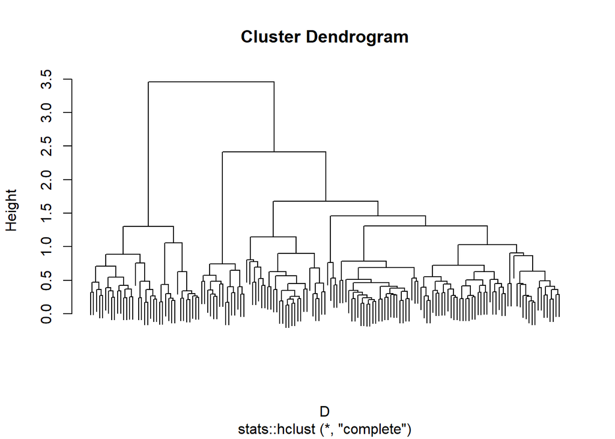

```r
subcjto = clust$grp.s$`3`[[2]] # segundo cluster para tres clusters
Clust$plotClust(clust, ts.as.lab = F)
```

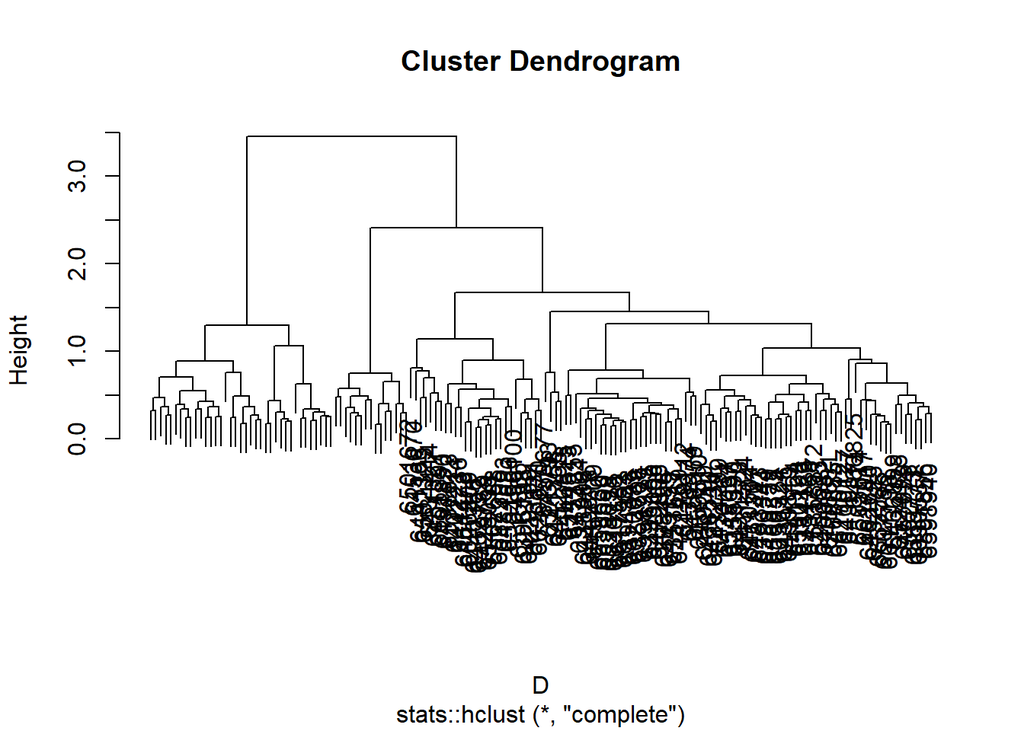

```r
Clust$plotClust(clust, subcjto, ts.as.lab = F)
```

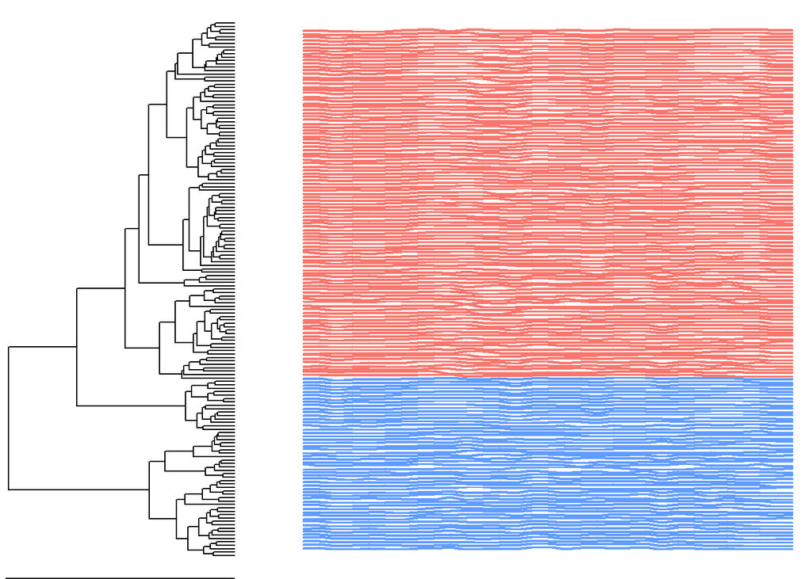

```r
Clust$plotClust(clust, subcjto, ts.as.lab = T)
```

```
## [2022-03-11 12:55:31] Guardando ./saves/en/TSclust_EUCL_Verdor_NDVI_scl_7_8_9_Mean_11.png
```

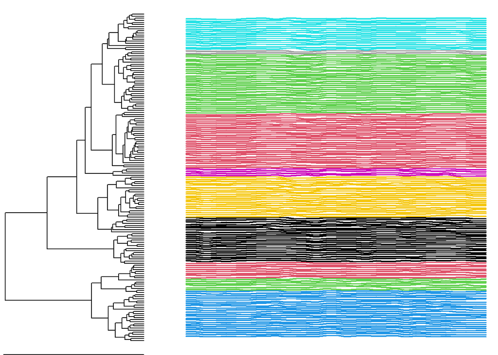

```r
Clust$plotClust(clust, k = 11L, ts.as.lab = T, f_save = png) # bmp, jpeg, tiff
```

# 4 Tarea 5.2. Modelos para cada cluster (`Clust.R`)

## 4.1 Procesamiento

> La función que hay que llamar para probar el escenario 3 (un modelo para cada grupo de contratos) es `Clust$initResultsClust()`. Ésta se apoya en `Clust$probarClust()` y en `Clust$promediarResults()`.

`Clust$probarClust()` se apoya en `ML$probarModelo()`, haciendo **una llamada para cada cluster DISTINTO**. Ya que el clustering es jerárquico, cuando pasamos de, por ejemplo, 5 clusters a 6 clusters, todos los clusters son los mismos menos 1 que se divide en 2, por lo que sólo tenemos que entrenar 2 modelos, pues ya tenemos los resultados de los otros 4. Recuerda que `ML$probarModelo()` guarda los resultados en un fichero aparte. SOLO SE PRUEBA PARA PCA=0, es decir, SIN APLICAR PCA.

Para cada posible cantidad de clusters, `ML$promediarResults()` saca la media de los resultados de cada cluster, de modo que cada parque tenga el mismo peso. Puesto que guardamos los resultados por cluster y no por contrato (pero se entiende que todos los contratos del mismo cluster tienen el mismo resultado) esto es una media ponderada donde el peso de cada cluster es proporcional al número de parques que lo compone. **Cuando no se pueden obtener resultados para alguno de los grupos**, se toman los resultados del primer grupo que lo contiene (para un número menor de clusters) y sí tiene resultados. El cómputo total de tiempo de ejecución es más sencillo, pues simplemente es sumar los tiempos de ejecución de cada cluster.

```r
# No ejecutar (tarda más de 3d)
Clust$initResultsClusts(series = dflt$series, pkgs = "pdc")
Clust$initResultsClusts(series = dflt$serie, pkgs = "TSclust")
```

## 4.2 Leyendo los ficheros

Para leer los resultados de un conjunto de datos, un modelo y un clustering del escenario 3:

```r
str(Clust$leerResultsClust())
```

```
## Classes 'data.table' and 'data.frame':   77 obs. of  11 variables:
##  $ n      : int  2 3 4 5 6 7 8 9 10 11 ...
##  $ PCA    : int  0 0 0 0 0 0 0 0 0 0 ...
##  $ MAE    : num  0.0612 0.0596 0.0586 0.0581 0.0573 ...
##  $ MAPE   : num  0.247 0.244 0.243 0.242 0.239 ...
##  $ MSE    : num  0.00776 0.00723 0.00695 0.00691 0.00675 ...
##  $ RMSE   : num  0.0874 0.0845 0.0828 0.0821 0.0809 ...
##  $ CV     : num  0.391 0.391 0.39 0.39 0.39 ...
##  $ CVRMSE : num  0.232 0.228 0.226 0.225 0.221 ...
##  $ user   : num  31 27.4 23.2 23 20.2 ...
##  $ system : num  0.75 0.87 0.25 0.14 0.15 ...
##  $ elapsed: num  2412 2133 1675 1603 1349 ...
##  - attr(*, ".internal.selfref")=<externalptr>
##  - attr(*, "param")=List of 9
##   ..$ ind  : chr "NDVI"
##   ..$ mask : chr "scl_7_8_9"
##   ..$ agg  : chr "Mean"
##   ..$ crop : chr "tall"
##   ..$ int  : chr "redim"
##   ..$ model: chr "rf"
##   ..$ serie: chr "Verdor"
##   ..$ pkg  : chr "TSclust"
##   ..$ diss : chr "EUCL"
```

Para leer los resultados de un conjunto de datos, varios modelos y varios clustering del escenario 3:

```r
str(res_pdc <- Clust$readResultsClust(series = dflt$series, pkgs = "pdc",
                                      models = dflt$models[5:6]))
```

```
## Classes 'data.table' and 'data.frame':   460 obs. of  15 variables:
##  $ Model  : chr  "gbm" "gbm" "gbm" "gbm" ...
##  $ Serie  : chr  "Riego" "Riego" "Riego" "Riego" ...
##  $ Pkg    : chr  "pdc" "pdc" "pdc" "pdc" ...
##  $ Diss   : chr  NA NA NA NA ...
##  $ n      : int  2 3 4 5 6 7 8 9 10 11 ...
##  $ PCA    : int  0 0 0 0 0 0 0 0 0 0 ...
##  $ MAE    : num  0.0702 0.0708 0.0712 0.072 0.0727 ...
##  $ MAPE   : num  0.296 0.303 0.298 0.302 0.307 ...
##  $ MSE    : num  0.00991 0.01008 0.01012 0.01031 0.01037 ...
##  $ RMSE   : num  0.0995 0.1004 0.1004 0.1012 0.1014 ...
##  $ CV     : num  0.393 0.393 0.393 0.393 0.393 ...
##  $ CVRMSE : num  0.253 0.256 0.257 0.259 0.259 ...
##  $ user   : num  2.15 3.02 4.16 5.3 6.36 ...
##  $ system : num  0.04 0.08 0.17 0.2 0.23 ...
##  $ elapsed: num  35.5 37 39.6 41 43.7 ...
##  - attr(*, ".internal.selfref")=<externalptr>
##  - attr(*, "param")=List of 5
##   ..$ ind : chr "NDVI"
##   ..$ mask: chr "scl_7_8_9"
##   ..$ agg : chr "Mean"
##   ..$ crop: chr "tall"
##   ..$ int : chr "redim"
```

```r
res_pdc %<>%
  dplyr::rename(Time = elapsed) %>%
  dplyr::mutate_at("Time", lubridate::seconds_to_period) %>%
  # dplyr::mutate_if(is.numeric, round, 4) %>%
  dplyr::select(!c(Pkg, Diss, PCA, CV, user, system))
summary(res_pdc %>% dplyr::mutate_if(is.character, factor))
```

```
##  Model             Serie           n              MAE               MAPE
##  gbm:230   Riego      :152   Min.   : 2.00   Min.   :0.06672   Min.   :0.2700
##  rf :230   Verdor     :154   1st Qu.:21.00   1st Qu.:0.07367   1st Qu.:0.3017
##            VerdorMulti:154   Median :40.00   Median :0.07472   Median :0.3056
##                              Mean   :39.83   Mean   :0.07515   Mean   :0.3069
##                              3rd Qu.:59.00   3rd Qu.:0.07707   3rd Qu.:0.3125
##                              Max.   :78.00   Max.   :0.07983   Max.   :0.3266
##       MSE                RMSE             CVRMSE
##  Min.   :0.009142   Min.   :0.09544   Min.   :0.2428
##  1st Qu.:0.010487   1st Qu.:0.09998   1st Qu.:0.2594
##  Median :0.010845   Median :0.10194   Median :0.2628
##  Mean   :0.010840   Mean   :0.10190   Mean   :0.2636
##  3rd Qu.:0.011253   3rd Qu.:0.10366   3rd Qu.:0.2685
##  Max.   :0.011801   Max.   :0.10690   Max.   :0.2759
##       Time
##  Min.   :34.1499999999996S
##  1st Qu.:1M 30.8750000000018S
##  Median :5M 30.185000000006S
##  Mean   :7M 57.3986304347823S
##  3rd Qu.:12M 10.5074999999978S
##  Max.   :55M 32.75S
```

```r
str(res_TSclust <- Clust$readResultsClust(series = dflt$serie, pkgs = "TSclust",
                                          disss = dflt$disss[-c(26,27,33)],
                                          models = dflt$models[5:6]))
```

```
## Classes 'data.table' and 'data.frame':   4928 obs. of  15 variables:
##  $ Model  : chr  "gbm" "gbm" "gbm" "gbm" ...
##  $ Serie  : chr  "Verdor" "Verdor" "Verdor" "Verdor" ...
##  $ Pkg    : chr  "TSclust" "TSclust" "TSclust" "TSclust" ...
##  $ Diss   : chr  "EUCL" "EUCL" "EUCL" "EUCL" ...
##  $ n      : int  2 3 4 5 6 7 8 9 10 11 ...
##  $ PCA    : int  0 0 0 0 0 0 0 0 0 0 ...
##  $ MAE    : num  0.0646 0.064 0.0612 0.0615 0.0608 ...
##  $ MAPE   : num  0.266 0.265 0.257 0.256 0.255 ...
##  $ MSE    : num  0.00836 0.00811 0.0075 0.00754 0.00738 ...
##  $ RMSE   : num  0.091 0.0896 0.0861 0.0857 0.0845 ...
##  $ CV     : num  0.391 0.391 0.39 0.39 0.39 ...
##  $ CVRMSE : num  0.244 0.243 0.237 0.235 0.232 ...
##  $ user   : num  1.85 2.7 3.32 3.69 4.4 ...
##  $ system : num  0.03 0.04 0.06 0.06 0.07 ...
##  $ elapsed: num  33.4 34.1 38.9 38.2 39.9 ...
##  - attr(*, ".internal.selfref")=<externalptr>
##  - attr(*, "param")=List of 5
##   ..$ ind : chr "NDVI"
##   ..$ mask: chr "scl_7_8_9"
##   ..$ agg : chr "Mean"
##   ..$ crop: chr "tall"
##   ..$ int : chr "redim"
```

```r
res_TSclust %<>%
  dplyr::rename(Time = elapsed) %>%
  dplyr::mutate_at("Time", lubridate::seconds_to_period) %>%
  # dplyr::mutate_if(is.numeric, round, 4) %>%
  dplyr::select(!c(Pkg, Serie, PCA, CV, user, system))
summary(res_TSclust %>% dplyr::mutate_if(is.character, factor))
```

```
##  Model               Diss            n           MAE               MAPE
##  gbm:2464   ACFG       : 154   Min.   : 2   Min.   :0.05514   Min.   :0.2285
##  rf :2464   ACFU       : 154   1st Qu.:21   1st Qu.:0.06686   1st Qu.:0.2709
##             AR.LPC.CEPS: 154   Median :40   Median :0.07022   Median :0.2848
##             AR.PIC     : 154   Mean   :40   Mean   :0.06926   Mean   :0.2817
##             CDM        : 154   3rd Qu.:59   3rd Qu.:0.07282   3rd Qu.:0.2963
##             CDMsym     : 154   Max.   :78   Max.   :0.07947   Max.   :0.3202
##             (Other)    :4004
##       MSE                RMSE             CVRMSE
##  Min.   :0.006366   Min.   :0.07751   Min.   :0.2122
##  1st Qu.:0.008874   1st Qu.:0.09076   1st Qu.:0.2387
##  Median :0.009713   Median :0.09528   Median :0.2513
##  Mean   :0.009485   Mean   :0.09384   Mean   :0.2487
##  3rd Qu.:0.010270   3rd Qu.:0.09852   3rd Qu.:0.2606
##  Max.   :0.011977   Max.   :0.10671   Max.   :0.2793
##
##       Time
##  Min.   :30.8700000000027S
##  1st Qu.:1M 33.4625000000025S
##  Median :5M 52.7200000000135S
##  Mean   :7M 50.2296469155863S
##  3rd Qu.:11M 50.2999999999797S
##  Max.   :2H 41M 37.1800000000003S
##
```

## 4.3 Guardando

Nos quedamos con los mejores resultados para cada clustering y los guardamos:

```r
(best_pdc <- res_pdc %>% dplyr::group_by(Serie, Model) %>%
    dplyr::slice_min(CVRMSE) %>% dplyr::ungroup() %>%
    dplyr::mutate_if(is.numeric, round, 4)) %>%
  dplyr::select(!c(MAE,MAPE,MSE,RMSE))
```

| Model | Serie | n | CVRMSE | Time |
| --- | --- | --- | --- | --- |
| gbm | Riego | 2 | 0.2534 | 35.47S |
| rf | Riego | 2 | 0.2500 | 40M 10.78S |
| gbm | Verdor | 2 | 0.2509 | 34.15S |
| rf | Verdor | 2 | 0.2428 | 55M 32.75S |
| gbm | VerdorMulti | 7 | 0.2508 | 43.83S |
| rf | VerdorMulti | 2 | 0.2485 | 39M 4.97S |

```r
# escribirTablaLatex(best_pdc, "pdc", F)
```

```r
(best_TSclust <- res_TSclust %>% dplyr::group_by(Diss, Model) %>%
    dplyr::slice_min(CVRMSE) %>% dplyr::ungroup() %>%
    dplyr::arrange(factor(Diss, levels = dflt$disss)) %>%
    dplyr::mutate_if(is.numeric, round, 4)) %>%
  dplyr::select(!c(MAE,MAPE,MSE,RMSE))
```

| Model | Diss | n | CVRMSE | Time |
| --- | --- | --- | --- | --- |
| gbm | EUCL | 19 | 0.2199 | 1M 3.82S |
| rf | EUCL | 11 | 0.2122 | 17M 47.99S |
| gbm | FRECHET | 12 | 0.2211 | 52.93S |
| rf | FRECHET | 10 | 0.2148 | 18M 57.32S |
| gbm | DTWARP | 25 | 0.2197 | 1M 6.87S |
| rf | DTWARP | 17 | 0.2136 | 17M 24.09S |
| gbm | CORT.EUCL | 44 | 0.2237 | 1M 31.26S |
| rf | CORT.EUCL | 35 | 0.2170 | 12M 17.91S |
| gbm | CORT.FRECHET | 16 | 0.2247 | 53.86S |
| rf | CORT.FRECHET | 15 | 0.2168 | 16M 24.56S |

[output cut: 54 more lines]

```r
# escribirTablaLatex(best_TSclust, "TSclust", F)
best_TSclust_gbm <- best_TSclust %>%
  dplyr::filter(Model == "gbm") %>% dplyr::select(!Model)
escribirTablaLatex(best_TSclust_gbm, "gbm", F)
```

```
## [2022-03-11 12:55:34] Guardando tabla ./saves/en/gbm.txt
```

```r
best_TSclust_rf  <- best_TSclust %>%
  dplyr::filter(Model == "rf") %>% dplyr::select(!Model)
escribirTablaLatex(best_TSclust_rf , "rf" , F)
```

```
## [2022-03-11 12:55:34] Guardando tabla ./saves/en/rf.txt
```

## 4.4 Algunas observaciones

```r
# como de mejores son los resultados obtenidos por rf frente a gbm
summary(best_TSclust_gbm$CVRMSE - best_TSclust_rf$CVRMSE)
```

```
##     Min.  1st Qu.   Median     Mean  3rd Qu.     Max.
## 0.000700 0.004200 0.005550 0.005513 0.007175 0.010200
```

```r
# cuanto aumenta el tiempo de ejecucion de rf frente a gbm
summary(best_TSclust_rf$Time / best_TSclust_gbm$Time)
```

```
##    Min. 1st Qu.  Median    Mean 3rd Qu.    Max.
##   8.086  16.199  54.698  50.772  66.774 269.591
```

**El uso de `pdc` no mejora los resultados sin aplicar clustering**.

```r
best_pdc_vs_None <- dplyr::bind_rows(
  res_todos %>% dplyr::select(!Scenario) %>%
    dplyr::mutate(Serie = "None", .before = n),
  best_pdc)
best_pdc_vs_None %>% dplyr::arrange(Model, CVRMSE) %>%
  dplyr::select(!c(MAE,MAPE,MSE,RMSE))
```

| Serie | n | Model | CVRMSE | Time |
| --- | --- | --- | --- | --- |
| None | 1 | gbm | 0.2490 | 38.23S |
| VerdorMulti | 7 | gbm | 0.2508 | 43.83S |
| Verdor | 2 | gbm | 0.2509 | 34.15S |
| Riego | 2 | gbm | 0.2534 | 35.47S |
| None | 1 | rf | 0.2411 | 49M 12.47S |
| Verdor | 2 | rf | 0.2428 | 55M 32.75S |
| VerdorMulti | 2 | rf | 0.2485 | 39M 4.97S |
| Riego | 2 | rf | 0.2500 | 40M 10.78S |

**`TSclust` sí consigue alguna mejora para algunas métricas**:

- para `gbm` hay 21 métricas por encima de `Diss=="None"` y 11 por debajo,
- para `rf` hay 19 métricas por encima de `Diss=="None"` y 13 por debajo)

```r
best_TSclust_vs_None <- dplyr::bind_rows(
  res_todos %>% dplyr::select(!Scenario) %>%
    dplyr::mutate(Diss = "None", .before = n),
  best_TSclust)
best_TSclust_vs_None %>% dplyr::arrange(Model, CVRMSE) %>%
  dplyr::select(!c(MAE,MAPE,MSE,RMSE))
```

| Diss | n | Model | CVRMSE | Time |
| --- | --- | --- | --- | --- |
| DTWARP | 25 | gbm | 0.2197 | 1M 6.87S |
| EUCL | 19 | gbm | 0.2199 | 1M 3.82S |
| FRECHET | 12 | gbm | 0.2211 | 52.93S |
| CID | 12 | gbm | 0.2217 | 45.26S |
| CORT.EUCL | 44 | gbm | 0.2237 | 1M 31.26S |
| CORT.DTW | 5 | gbm | 0.2238 | 37.74S |
| CORT.FRECHET | 16 | gbm | 0.2247 | 53.86S |
| SPEC.ISD | 3 | gbm | 0.2361 | 36.25S |
| SPEC.GLK | 3 | gbm | 0.2366 | 33.18S |
| SPEC.WLS | 4 | gbm | 0.2379 | 36.83S |

[output cut: 56 more lines]

> Ojo con los tiempos!

Este es el tiempo que habríamos tardado si hubiéramos repetido casos:

```r
sum.period(res_pdc$Time, res_TSclust$Time)
```

```
## [1] "29d 8H 41M 35.0700000091456S"
```

```r
# Solo TSclust
# sum.period(res_TSclust$Time)
res_TSclust %>% dplyr::group_by(Model) %>% dplyr::summarise_at("Time", sum.period)
```

| Model | Time |
| --- | --- |
| gbm | 2d 16H 8M 9.17000001104316S |
| rf | 24d 3H 33M 22.5299999983981S |

```r
# res_TSclust %>% dplyr::group_by(Model,Diss) %>% dplyr::summarise_at("Time", sum.period)
```

Y éste es el tiempo que hemos tardado realmente en la segunda tanda de pruebas:

```r
res <- list(gbm = ML$leerResults(model = "gbm", pca = 0L),
            rf = ML$leerResults(model = "rf", pca = 0L)) %>%
  listDF2DF("Model") %>%
  dplyr::rename(Time = elapsed) %>%
  dplyr::mutate_at("Time", lubridate::seconds_to_period) %>%
  dplyr::select(!c(PCA,CV,user,system))
# sum.period(res$Time)
contratos <- dflt$contratos("ConSeries", dflt$ind, dflt$mask, dflt$agg)
res %<>% dplyr::filter(!Group %in% contratos,
                       Group != paste0(contratos, collapse = "_"))
# sum.period(res$Time)
res %>% dplyr::group_by(Model) %>% dplyr::summarise_at("Time", sum.period)
```

| Model | Time |
| --- | --- |
| gbm | 3H 7M 21.140000000205S |
| rf | 3d 17H 50M 55.7999999998137S |

## 4.5 Tarea 6.2. Visualización de datos (tablas e histogramas)

```r
ply <- F
dflt$lan
```

```
## [1] "en"
```

```r
lan = dflt$lan
carpeta = paths$saves(lan)
f_save <- "svg"
f_save <- "png"
# f_save <- NULL
```

```r
range(best_TSclust_vs_None$CVRMSE)
```

```
## [1] 0.2122 0.2551
```

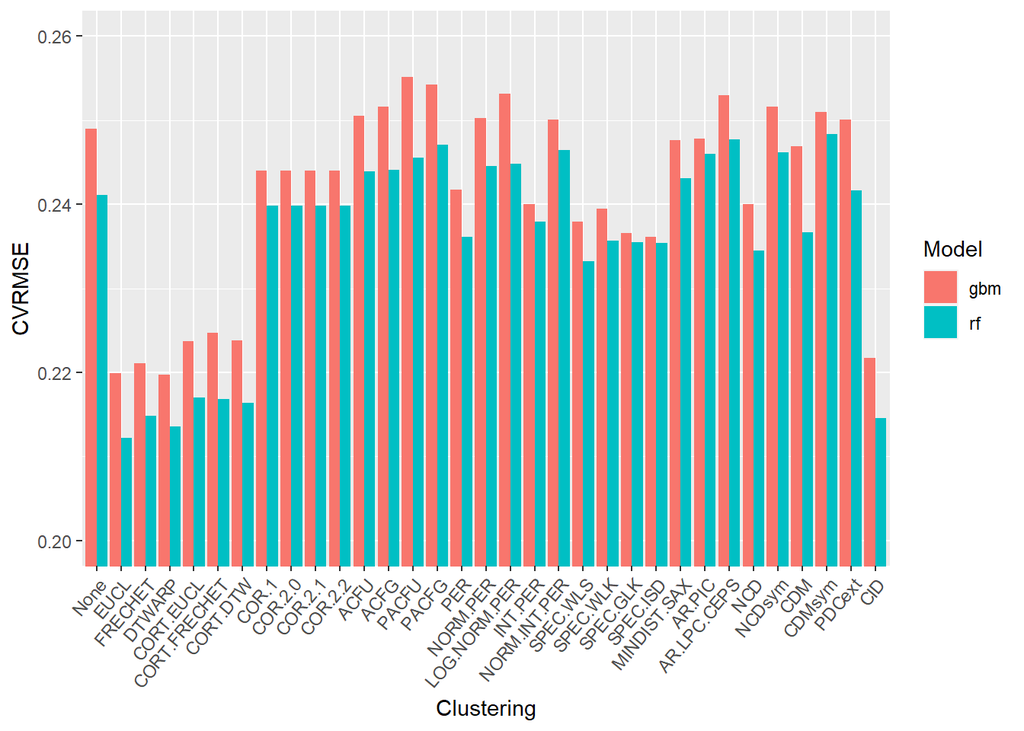

```r
best_TSclust_vs_None$Diss %<>% factor(levels = unique(.))

ggplot2::ggplot(best_TSclust_vs_None, ggplot2::aes(Diss, CVRMSE, fill = Model)) +
  ggplot2::geom_col(position = "dodge") +
  ggplot2::scale_x_discrete(guide = ggplot2::guide_axis(angle = 50)) +
  ggplot2::coord_cartesian(ylim = c(0.2,0.26)) +
  ggplot2::xlab("Clustering")
```

```r
fichero <- paste0("clust_vs_CVRMSE",".",f_save)
msg("Guardando ",fichero)
```

```
## [2022-03-11 12:55:35] Guardando clust_vs_CVRMSE.png
```

```r
ggplot2::ggsave(fichero, device = f_save, path = carpeta,
                width = 7, height = 5, units = "in")
```

Para ver la evolución del CVRMSE conforme varía el número de clusters para algunas de las métricas (las cuatro mejores, que coinciden para ambos modelos), añadimos el caso `n=1`, un clúster, es decir, sin aplicar clustering:

```r
head(res_TSclust_n_1 <- dplyr::bind_rows(
  tidyr::expand_grid(Diss = unique(res_TSclust$Diss),
                     res_todos %>% dplyr::select(!Scenario)),
  res_TSclust))
```

| Diss | n | Model | MAE | MAPE | MSE | RMSE | CVRMSE | Time |
| --- | --- | --- | --- | --- | --- | --- | --- | --- |
| EUCL | 1 | gbm | 0.0687 | 0.2922 | 0.0095 | 0.0977 | 0.2490 | 38.23S |
| EUCL | 1 | rf | 0.0656 | 0.2681 | 0.0089 | 0.0946 | 0.2411 | 49M 12.47S |
| FRECHET | 1 | gbm | 0.0687 | 0.2922 | 0.0095 | 0.0977 | 0.2490 | 38.23S |
| FRECHET | 1 | rf | 0.0656 | 0.2681 | 0.0089 | 0.0946 | 0.2411 | 49M 12.47S |
| DTWARP | 1 | gbm | 0.0687 | 0.2922 | 0.0095 | 0.0977 | 0.2490 | 38.23S |
| DTWARP | 1 | rf | 0.0656 | 0.2681 | 0.0089 | 0.0946 | 0.2411 | 49M 12.47S |

```r
(best_diss_4_TSclust <- best_TSclust %>%
  dplyr::group_by(Model) %>% dplyr::slice_min(CVRMSE, n = 4) %>%
  dplyr::ungroup() %>% dplyr::select(Model, Diss))
```

| Model | Diss |
| --- | --- |
| gbm | DTWARP |
| gbm | EUCL |
| gbm | FRECHET |
| gbm | CID |
| rf | EUCL |
| rf | DTWARP |
| rf | CID |
| rf | FRECHET |

```r
res_4_TSclust_n_1 <- dplyr::semi_join(res_TSclust_n_1,
                                      best_diss_4_TSclust)
```

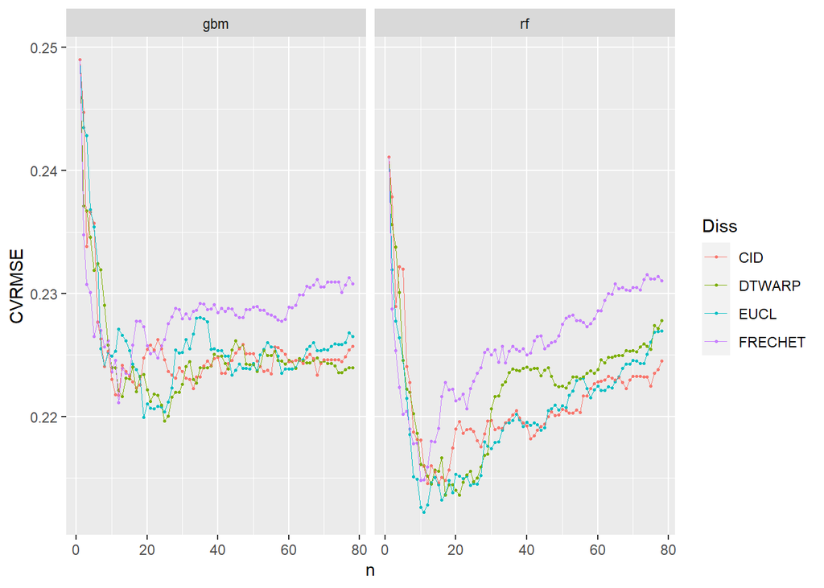

```r
ggplot2::ggplot(res_4_TSclust_n_1, ggplot2::aes(n, CVRMSE, colour = Diss)) +
  ggplot2::geom_point(size = 0.5) + ggplot2::geom_line(size = 0.1) +
  ggplot2::facet_wrap(ggplot2::vars(Model))
```

```r
fichero <- paste0("n_vs_CVRMSE",".",f_save)
msg("Guardando ",fichero)
```

```
## [2022-03-11 12:55:36] Guardando n_vs_CVRMSE.png
```

```r
ggplot2::ggsave(fichero, device = f_save, path = carpeta,
                width = 7, height = 5, units = "in")
```

> **¡IMPORTANTE!** No hay ninguna función que genere estos gráficos, pero sería lo recomendable para incluirlos en el dashboard. Mejor que de aquí, mirar el código de la última parte de `savesTFG.R` (para `lan = "sp"`) o de `savesPaper.R` (para `lan = "en"`).

# 5 Para continuar… (`lstm.R`)

Los modelos de `caret` son listas de funciones y metadatos, lo cual nos permite [definir nuestro propio modelo](https://topepo.github.io/caret/using-your-own-model-in-train.html), como LSTM.

`lstm.R` tiene un boceto (nunca llegué a probarlo y comprobar que funciona correctamente). Además, hay que tener en cuenta que este modelo aprende de observaciones pasadas, por lo que:

- no se pueden juntar observaciones de distintos parques así como así, una detras de otras…
- el particionamiento no puede ser aleatorio, sino que las primeras observaciones son train y las últimas son test (`ML$particionarDatos(random = F)`);
- lo mismo ocurre con el tunning de los parámetros… hay que cambiar el `control` (ver `ML$entrenarModelo()`).

Además, los datos no se normalizan, sino que se escalan al rango [-1,1] / [0,1] (`ML$preprocesarDatos(b = c(-1,1))`).